# PlotPLM

Hope Anderson

2026-11-12

```r
library(dunn.test)
```

```r
library(ggplot2)
library(dplyr)
library(tidyr)
library(stringr)
library(khroma)
library(tidytext)
library(pals)
```

# Data setup

```r
plot_data <- read.table("data_frame_results.txt", header=TRUE)
skipped <-   read.table("skipped_results.txt",    header = TRUE)
or_annotated <- read.table("or_gene_annotations.txt", header = TRUE)

#how many observations are omitted and for what reason?
nrow(skipped %>% filter(str_detect(reason, "branch length near zero")))
```

```
## [1] 14656
```

```r
nrow(skipped %>% filter(str_detect(reason, "missing taxa")))
```

```
## [1] 11316
```

```r
nrow(skipped %>% filter(str_detect(reason, "nnls.tree failed:")))
```

```
## [1] 3636
```

```r
nrow(plot_data)
```

```
## [1] 8480
```

# Mean branch length per region and type (domesticate vs wild)

Plot within group mean

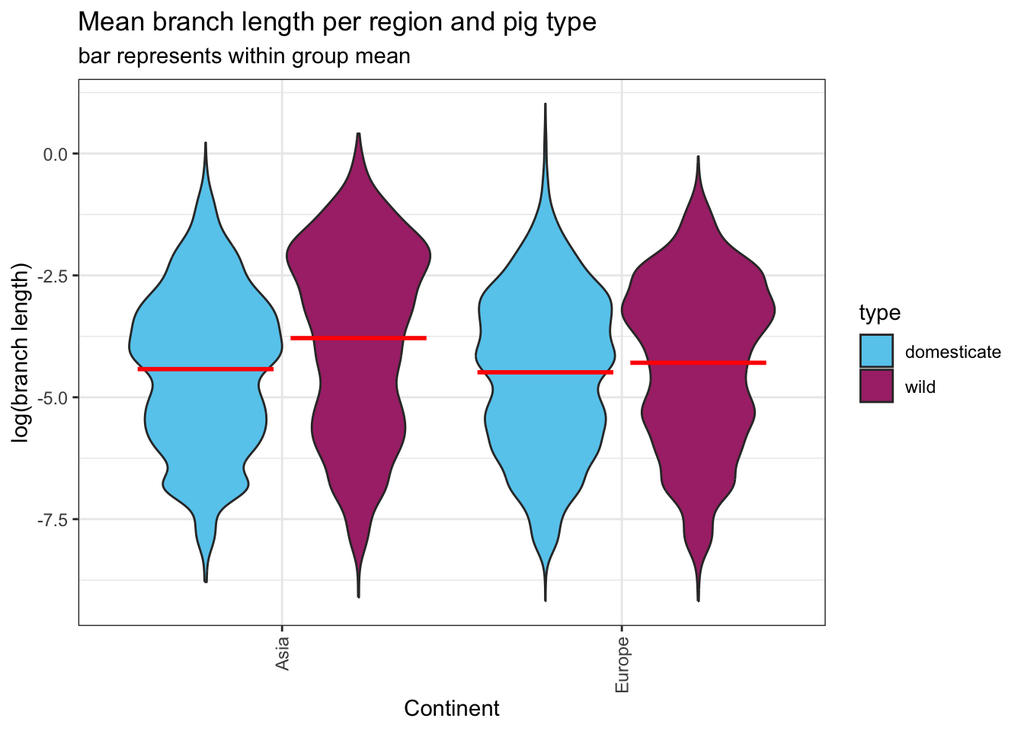

```r
to_plot_long <- plot_data %>%
  select(-comparison) %>%
  pivot_longer(cols = c(branch_len_wild, branch_len_dom),
               names_to = "status", values_to = "branch_len") %>%
  mutate(status = recode(status,
                          branch_len_wild = "wild",
                          branch_len_dom  = "domesticate"))

plot1 <- ggplot(to_plot_long, aes(x = region, y = log(branch_len), fill = status)) +
  geom_violin()+
  theme_bw()+
  labs(y="log(branch length)")+
  theme(axis.text.x = element_text(angle = 90, vjust = 0.5, hjust=1))+
  scale_fill_manual(values = unname(khroma::color("bright")(7))[c(5, 6)])+
  labs(x="Continent", fill="type",title="Mean branch length per region and pig type",subtitle = "bar represents within group mean")+
  stat_summary(
    fun = mean,
    geom = "crossbar",
    aes(group = status),
    position = position_dodge(width = 0.9),
    width = 0.8,
    color = "red",
    linewidth = 0.4,
    show.legend = FALSE
  )

plot2 <- ggplot(to_plot_long, aes(x = region, y = branch_len, fill = status)) +
  geom_violin()+
  theme_bw()+
  labs(y="branch length")+
  theme(axis.text.x = element_text(angle = 90, vjust = 0.5, hjust=1))

plot1
```

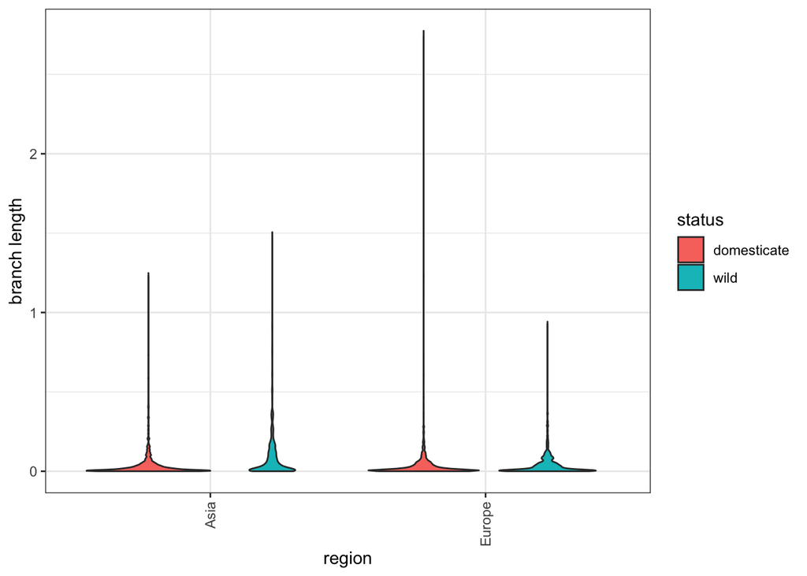

```r
plot2
```

```r
  ggsave(
    filename = paste0("for_paper_plots/mean_per_group_logged.png"),
    plot = plot1,
    width = 6,
    height = 4.5,
    limitsize = FALSE,
    create.dir = TRUE)
```

Optional – save the non logged version of the plot

```r
ggsave(
    filename = paste0("plots/branch_length.jpg"),
    plot = plot2,
    width = 6,
    height = 4.5,
    limitsize = FALSE,
    create.dir = TRUE)
```

plot as the ratio between the wild and the domesticate, so each gene is collapsed into one point

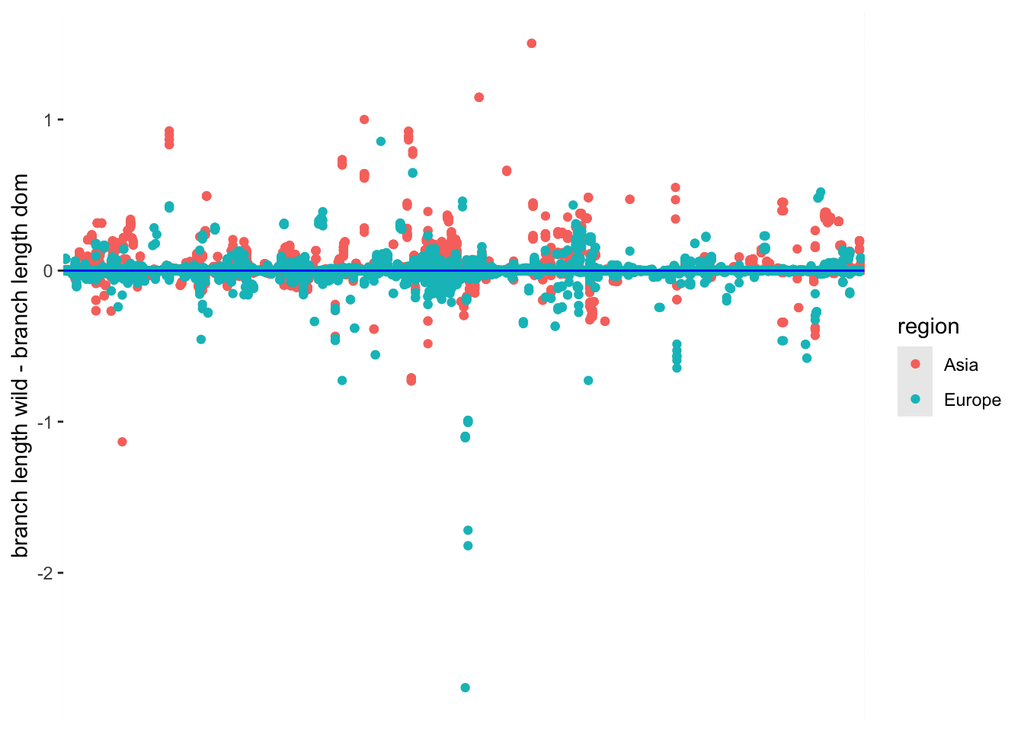

```r
plot_data <- plot_data %>% mutate(branch_length_diff = branch_len_wild - branch_len_dom)
plot_data <- plot_data %>% mutate(branch_length_ratio = branch_len_wild/branch_len_dom)

plot_3 <- ggplot(plot_data, aes(x=gene, y = branch_length_diff, color=region))+
  geom_point()+
  theme(axis.title.x=element_blank(),
        axis.text.x=element_blank(),
        axis.ticks.x=element_blank())+
  labs(y= "branch length wild - branch length dom")+
  geom_abline(intercept = 0, slope = 0, color = 'blue')

plot_4 <- ggplot(plot_data, aes(x=gene, y = branch_length_ratio, color=region))+
  geom_point()+
  theme(axis.title.x=element_blank(),
        axis.text.x=element_blank(),
        axis.ticks.x=element_blank())+
  labs(y= "branch length wild / branch length dom")+
  geom_abline(intercept = 1, slope = 0, color = 'blue')

plot_5 <- ggplot(plot_data, aes(x=gene, y = log(branch_length_ratio), color=region))+
  geom_point()+
  theme(axis.title.x=element_blank(),
        axis.text.x=element_blank(),
        axis.ticks.x=element_blank())+
  labs(y= "log(branch length wild / branch length dom)")+
  geom_abline(intercept = 0, slope = 0, color = 'blue')+
  facet_wrap(~region)

plot_3
```

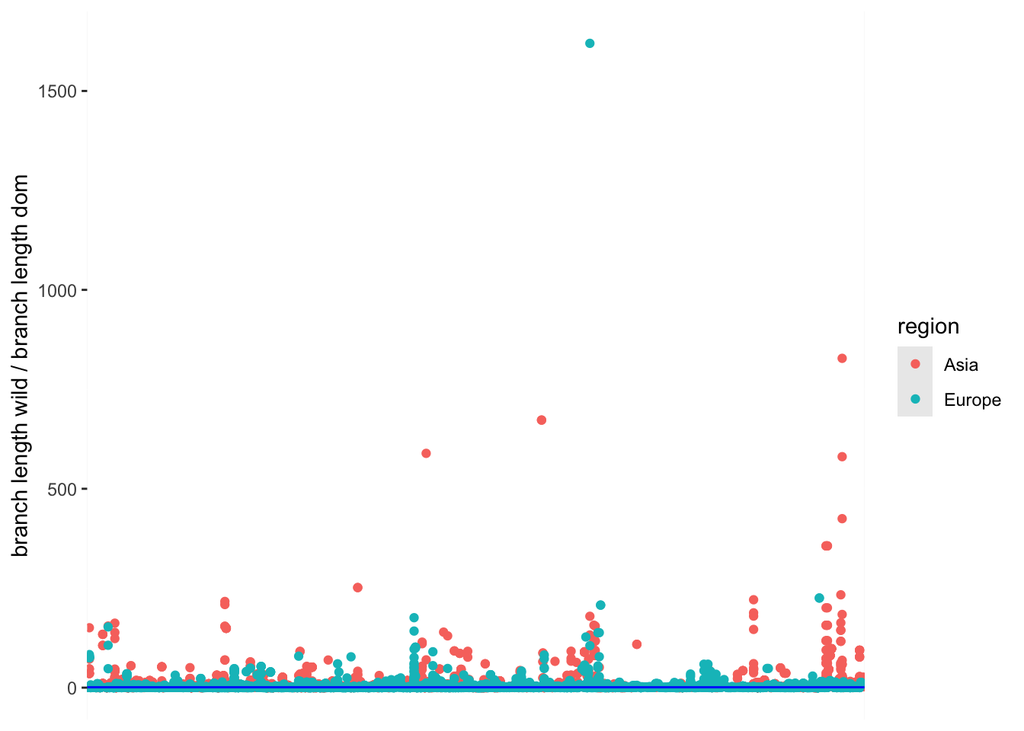

```r
plot_4
```

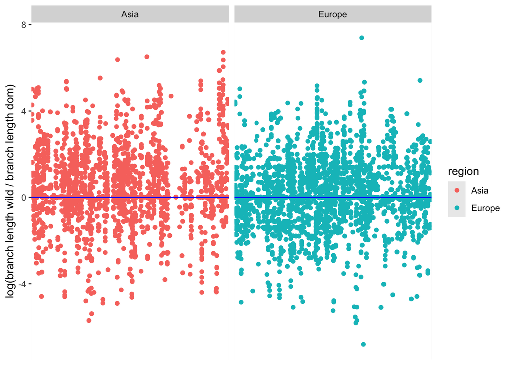

```r
plot_5
```

```r
ggsave(
    filename = paste0("plots/branch_length_diff.jpg"),
    plot = plot_3,
    width = 6,
    height = 4.5,
    limitsize = FALSE)

ggsave(
    filename = paste0("plots/branch_length_ratio.jpg"),
    plot = plot_5,
    width = 6,
    height = 4.5,
    limitsize = FALSE)
```

Optional, histogram to visualize the data distribution

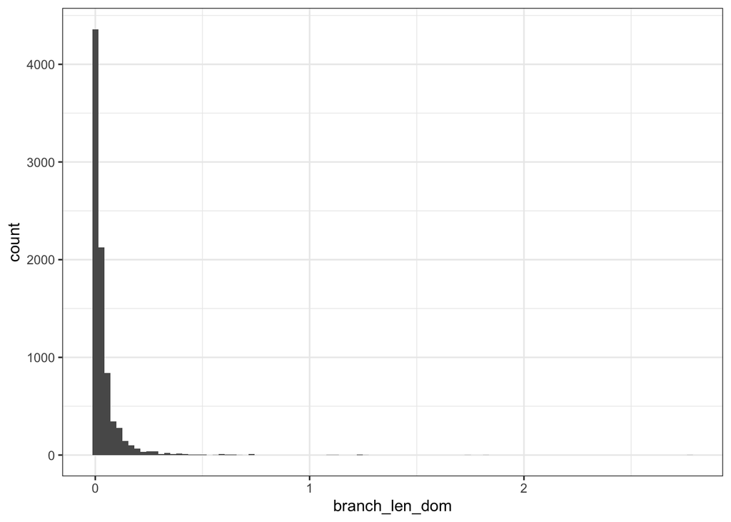

```r
ggplot(plot_data, aes(x=branch_len_dom))+
  geom_histogram(bins = 100)+
  theme_bw()
```

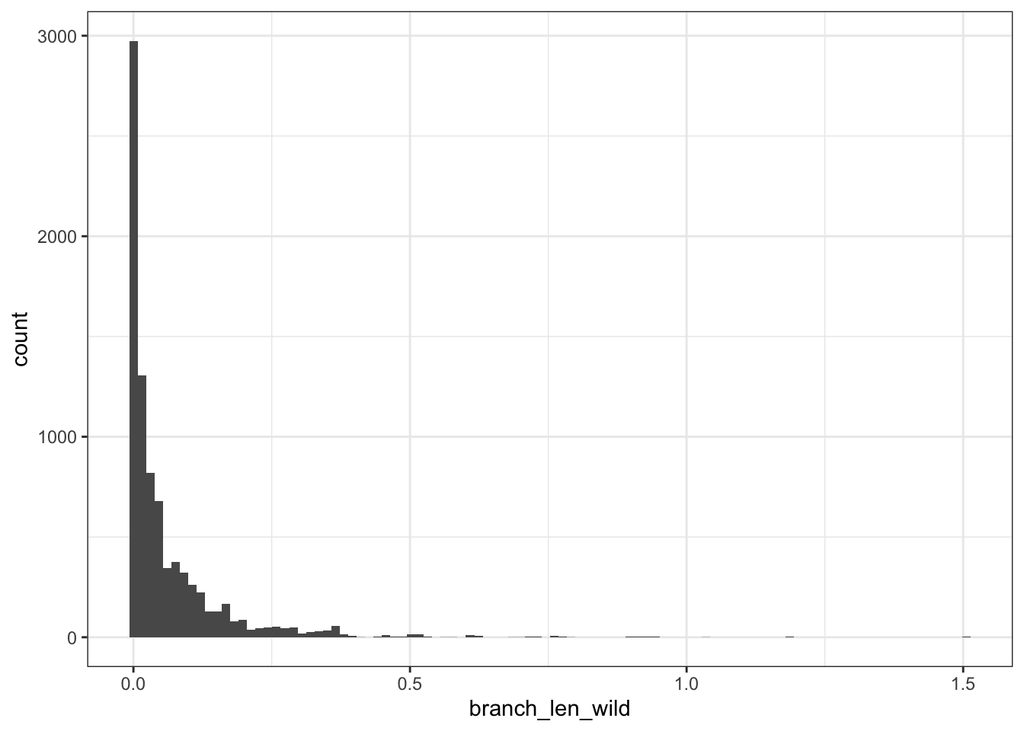

```r
ggplot(plot_data, aes(x=branch_len_wild))+
  geom_histogram(bins = 100)+
  theme_bw()
```

# Wilcox test within each region (wild vs. domesticate, is there a sig. difference in branch length?) wilcox test (paired) to test within each region, if there is a difference between the wild and the domesticate

```r
asia   <- plot_data %>% filter(region == "Asia")
europe <- plot_data %>% filter(region == "Europe")

wilcox.test(asia$branch_len_wild,   asia$branch_len_dom,   paired = TRUE)
```

```
##
##  Wilcoxon signed rank test with continuity correction
##
## data:  asia$branch_len_wild and asia$branch_len_dom
## V = 5835396, p-value < 2.2e-16
## alternative hypothesis: true location shift is not equal to 0
```

```r
wilcox.test(europe$branch_len_wild, europe$branch_len_dom, paired = TRUE)
```

```
##
##  Wilcoxon signed rank test with continuity correction
##
## data:  europe$branch_len_wild and europe$branch_len_dom
## V = 4666045, p-value < 2.2e-16
## alternative hypothesis: true location shift is not equal to 0
```

```r
mean(asia$branch_length_diff)
```

```
## [1] 0.04532744
```

```r
mean(europe$branch_length_diff)
```

```
## [1] 0.003750594
```

```r
mean(asia$branch_len_wild)
```

```
## [1] 0.08279642
```

```r
mean(asia$branch_len_dom)
```

```
## [1] 0.03746898
```

```r
mean(europe$branch_len_wild)
```

```
## [1] 0.04174277
```

```r
mean(europe$branch_len_dom)
```

```
## [1] 0.03799218
```

In both cases, the branch length is significantly higher in the wild than in the domesticate. Confirm this by simply checking the mean per each group. The difference is more pronounced in Asia than in Europe

Optional, violin plots of the difference (wild-domesticate)

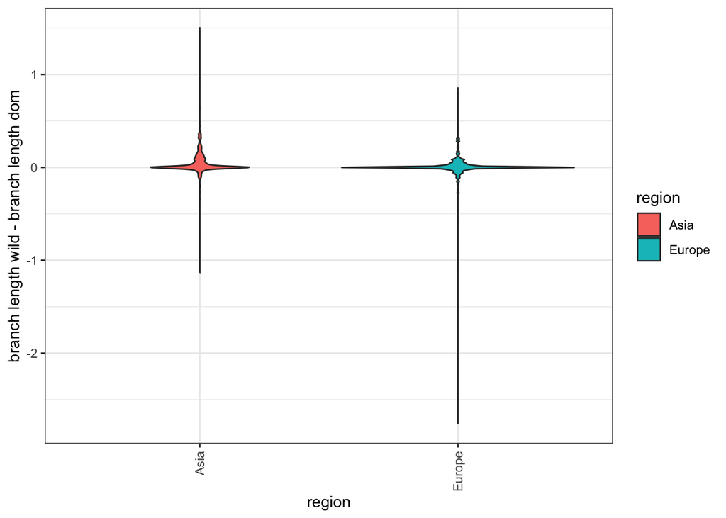

```r
p_diff <- ggplot(plot_data, aes(x = region, y = branch_length_diff, fill = region)) +
  geom_violin()+
  theme_bw()+
  labs(y="branch length wild - branch length dom")+
  theme(axis.text.x = element_text(angle = 90, vjust = 0.5, hjust=1))

p_ratio_violin <- ggplot(plot_data, aes(x=region, y = log(branch_length_ratio), fill=region))+
  geom_violin()+
  theme_bw()+
  labs(y= "log(branch length wild / branch length dom)")+
  theme(axis.text.x = element_text(angle = 90, vjust = 0.5, hjust=1))

p_diff
```

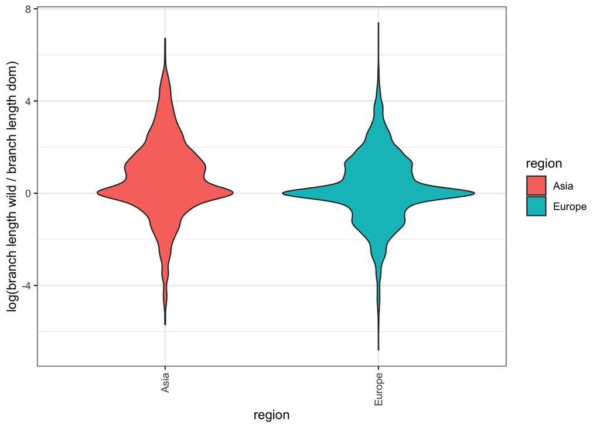

```r
p_ratio_violin
```

```r
ggsave(
    filename = paste0("plots/diff_violin.jpg"),
    plot = p_diff,
    width = 6,
    height = 4.5,
    limitsize = FALSE)


ggsave(
    filename = paste0("plots/ratio_violin.jpg"),
    plot = p_ratio_violin,
    width = 6,
    height = 4.5,
    limitsize = FALSE)
```

Optional bar plots to visualize the wilcox results

```r
europe_count_wild_greater <- 0
europe_count_domesticate_greater <- 0
europe_count_equal <- 0

for (i in seq_along(europe$gene)){
  sign <- europe[i, 9]
  if (sign > 0) {
    europe_count_wild_greater <- europe_count_wild_greater + 1
  }
  if (sign < 0) {
    europe_count_domesticate_greater <- europe_count_domesticate_greater + 1
  }
  else {
    europe_count_equal <- europe_count_equal + 1
  }
}
```

```r
asia_count_wild_greater <- 0
asia_count_domesticate_greater <- 0
asia_count_equal <- 0
```

```r
for (i in seq_along(asia$gene)){
  sign <- asia[i, 9]
  if (sign > 0) {
    asia_count_wild_greater <- asia_count_wild_greater + 1
  }
  if (sign < 0) {
    asia_count_domesticate_greater <- asia_count_domesticate_greater + 1
  }
  else {
    asia_count_equal <- asia_count_equal + 1
  }
}
```

```r
df_counts <- data.frame(
  region = c("Asia", "Europe"),
  wild_greater = c(asia_count_wild_greater, europe_count_wild_greater),
  equal = c(asia_count_equal, europe_count_equal),
  domesticate_greater = c(asia_count_domesticate_greater, europe_count_domesticate_greater))

df_counts_long <- df_counts %>% pivot_longer(cols = c(wild_greater,equal,domesticate_greater), names_to = "group", values_to = "count")

p_bar <- ggplot(df_counts_long, aes(x=region, y=count, fill=group))+
  geom_col()+
  theme_bw()+
  scale_fill_brewer()

ggsave(
    filename = paste0("plots/bar.jpg"),
    plot = p_bar,
    width = 6,
    height = 4.5,
    limitsize = FALSE)
```

```r
df_counts <- df_counts %>%
  mutate(wild_greater_prop =        wild_greater/        (wild_greater+equal+domesticate_greater),
         equal_prop =               equal/               (wild_greater+equal+domesticate_greater),
         domesticate_greater_prop = domesticate_greater/ (wild_greater+equal+domesticate_greater))

df_counts_long_prop <- df_counts %>%
  select (wild_greater_prop,equal_prop,domesticate_greater_prop, region) %>%
  pivot_longer(cols = c(wild_greater_prop,equal_prop,domesticate_greater_prop), names_to = "group", values_to = "count")

p_bar_prop <- ggplot(df_counts_long_prop, aes(x=region, y=count, fill=group))+
  geom_col()+
  theme_bw()+
  scale_fill_brewer()

ggsave(
    filename = paste0("plots/bar_prop.jpg"),
    plot = p_bar_prop,
    width = 6,
    height = 4.5,
    limitsize = FALSE)
```

# Plots by gene

## Chromosome

Plot by each gene. Now, instead of collapsing we want each gene as a single point, to see if there is a pattern between the genes affected by domestication in Asia and in Europe. Also, now our measure of interest is the log of the ratio between the wild and domesticate branch lenght. This is nice, because the log will be positive with the wild > domesticate, and negative when the wild < domesticate. Plot by chromosome.

Also, plot both the scatter plot and the rank of the genes, as a bar plot. Color them chromosome, to see if there is a chromosome that is contributing significantly to the pattern.

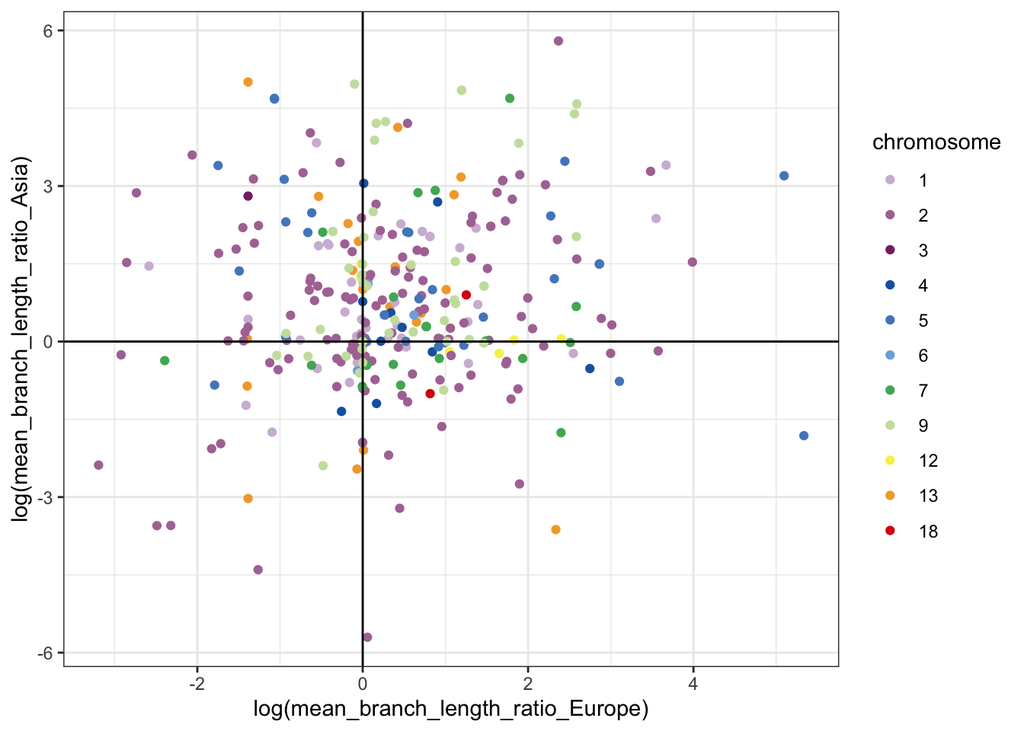

```r
plot_data_summary <- plot_data %>%
  select(-c(branch_len_wild, branch_len_dom)) %>%
  group_by(gene, region, chromosome) %>%
  summarise(
    mean_branch_length_ratio      = mean(branch_length_ratio, na.rm = TRUE),
    mean_branch_length_difference = mean(branch_length_diff, na.rm = TRUE),
    n      = n(),
    .groups = "drop"
  ) %>%
    mutate(
      chromosome = as.numeric(str_split_i(chromosome, "_", 2)),
      chromosome = factor(chromosome, levels = sort(unique(chromosome))))

plot_data_summary_wide <- plot_data_summary %>% pivot_wider(names_from  = region,
                                                    values_from = c(mean_branch_length_ratio, mean_branch_length_difference, n)) %>% drop_na() %>%
  mutate(n=n_Europe+n_Asia,
         log_eu   = log(mean_branch_length_ratio_Europe),
         log_asia = log(mean_branch_length_ratio_Asia),
         quadrant = case_when(
           log_eu >  0 & log_asia >  0 ~ "Both Asia and Europe wild > domesticate",
           log_eu <= 0 & log_asia >  0 ~ "Asia only wild > domesticate",
           log_eu >  0 & log_asia <= 0 ~ "Europe only wild > domesticate",
           log_eu <= 0 & log_asia <= 0 ~ "Both Asia and Europe wild < domesticate"))

chrom_cols <- setNames(
  colour("discrete rainbow")(nlevels(plot_data_summary$chromosome)),
  levels(plot_data_summary$chromosome)
)

p_quad <- ggplot(plot_data_summary_wide, aes(x=log(mean_branch_length_ratio_Europe), y=log(mean_branch_length_ratio_Asia), color = chromosome))+
  geom_point()+
  theme_bw()+
  geom_hline(yintercept = 0)+
  geom_vline(xintercept = 0)+
  scale_color_manual(values = chrom_cols)

p_col <- ggplot(plot_data_summary,
       aes(x = reorder_within(gene, -mean_branch_length_ratio, region),
           y = log(mean_branch_length_ratio),
           fill = chromosome, color = chromosome)) +
  geom_col(width = 1, linewidth = 0.3) +
  geom_hline(yintercept = 0) +
  facet_wrap(~region, scales = "free_x") +
  scale_x_reordered() +
  scale_fill_manual(values = chrom_cols) +
  scale_color_manual(values = chrom_cols) +
  labs(x = "Genes (ranked within region)") +
  theme_bw() +
  theme(axis.text.x = element_blank(),
        axis.ticks.x = element_blank(),
        panel.grid.major.x = element_blank())

p_col_by_chrom <- plot_data_summary %>%
  mutate(panel = paste(region, chromosome)) %>%
  ggplot(aes(x = reorder_within(gene, -mean_branch_length_ratio, panel),
             y = log(mean_branch_length_ratio),
             fill = chromosome, color = chromosome)) +
  geom_col(width = 1, linewidth = 0.3) +
  geom_hline(yintercept = 0) +
  facet_wrap(region ~ chromosome, scales = "free_x") +
  scale_x_reordered() +
  scale_fill_manual(values = chrom_cols) +
  scale_color_manual(values = chrom_cols) +
  labs(x = "Genes (ranked within panel)") +
  theme_bw() +
  theme(axis.text.x = element_blank(),
        axis.ticks.x = element_blank(),
        panel.grid.major.x = element_blank(),
        legend.position = "none")

ggsave(
    filename = paste0("plots/by_chromosome/quad_scatter.jpg"),
    plot = p_quad,
    width = 8,
    height = 4.5,
    limitsize = FALSE)

ggsave(
    filename = paste0("plots/by_chromosome/bar_rank.jpg"),
    plot = p_col,
    width = 12, height = 5, dpi = 300, limitsize = FALSE)

ggsave(
    filename = paste0("plots/by_chromosome/bar_rank_chrom.jpg"),
    plot = p_col_by_chrom,
    width = 12, height = 8, dpi = 300, limitsize = FALSE)

p_quad
```

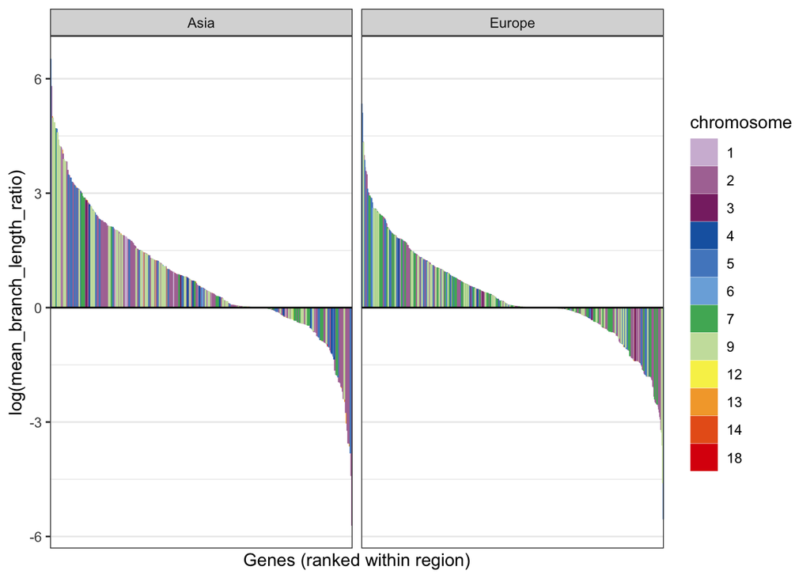

```r
p_col
```

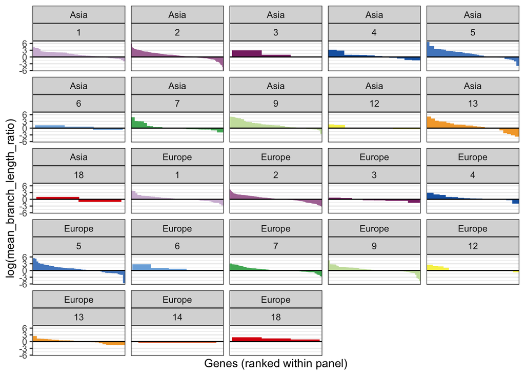

```r
p_col_by_chrom
```

Quadrant plot is interesting (we’ll come back to that later.) Chromosome is difficult to interpret.

## Family

Now, we can try to color the genes by family.

```r
colnames(or_annotated) <- c("gene", "Family", "Subfamily", "Member")

plot_data_summary <- plot_data_summary %>%
  mutate (gene = str_split_i(gene, "_", 3))

or_annotated <- or_annotated %>%
  mutate(in_results = as.character(gene) %in% unique(as.character(plot_data_summary$gene)))

length(unique(plot_data$gene))
```

```
## [1] 579
```

```r
length(unique(or_annotated$gene))
```

```
## [1] 973
```

```r
nrow(or_annotated %>% filter(in_results == TRUE))
```

```
## [1] 526
```

```r
plot_data_summary_gene_family <- plot_data_summary %>%
  left_join(or_annotated, by = 'gene')

plot_data_summary_gene_family %>% filter(is.na(Family)) %>% pull(gene) %>% unique() %>% length()
```

```
## [1] 53
```

```r
plot_data_summary_gene_family <- plot_data_summary_gene_family %>% filter(is.na(Family)==FALSE)

plot_data_summary_gene_family$Family <-as.factor(plot_data_summary_gene_family$Family)
```

Same plot as before (genes ranked) but colored by gene family.

```r
family_cols <- setNames(
  colour("discrete rainbow")(nlevels(plot_data_summary_gene_family$Family)),
  levels(plot_data_summary_gene_family$Family)
)

p_col_function <- ggplot(plot_data_summary_gene_family,
       aes(x = reorder_within(gene, -mean_branch_length_ratio, region),
           y = log(mean_branch_length_ratio),
           fill = Family, color = Family)) +
  geom_col(width = 1, linewidth = 0.3) +
  geom_hline(yintercept = 0) +
  facet_wrap(~region, scales = "free_x") +
  scale_x_reordered() +
  scale_fill_manual(values = family_cols) +
  scale_color_manual(values = family_cols) +
  labs(x = "Genes (ranked within region)") +
  theme_bw() +
  theme(axis.text.x = element_blank(),
        axis.ticks.x = element_blank(),
        panel.grid.major.x = element_blank())

p_col_function_global_order <- ggplot(plot_data_summary_gene_family,
       aes(x = reorder(gene, -mean_branch_length_ratio),
           y = log(mean_branch_length_ratio),
           fill = Family, color = Family)) +
  geom_col(width = 1, linewidth = 0.3) +
  geom_hline(yintercept = 0) +
  facet_wrap(~region, scales = "free_x") +
  scale_x_reordered() +
  scale_fill_manual(values = family_cols) +
  scale_color_manual(values = family_cols) +
  labs(x = "Genes") +
  theme_bw() +
  theme(axis.text.x = element_blank(),
        axis.ticks.x = element_blank(),
        panel.grid.major.x = element_blank())

p_col_by_chrom_function <- plot_data_summary_gene_family %>%
  mutate(panel = paste(region, chromosome)) %>%
  ggplot(aes(x = reorder_within(gene, -mean_branch_length_ratio, panel),
             y = log(mean_branch_length_ratio),
             fill = Family, color = Family)) +
  geom_col(width = 1, linewidth = 0.3) +
  geom_hline(yintercept = 0) +
  facet_wrap(region ~ chromosome, scales = "free_x") +
  scale_x_reordered() +
  scale_fill_manual(values = family_cols) +
  scale_color_manual(values = family_cols) +
  labs(x = "Genes (ranked within panel)") +
  theme_bw() +
  theme(axis.text.x = element_blank(),
        axis.ticks.x = element_blank(),
        panel.grid.major.x = element_blank(),
        legend.position = "none")
```

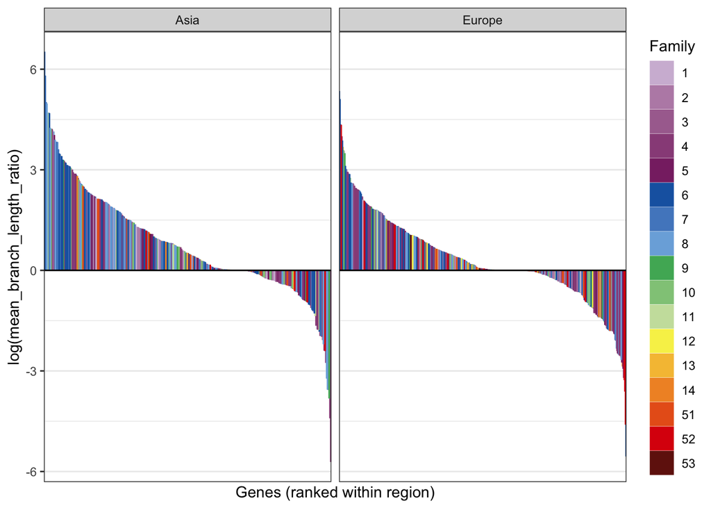

```r
ggsave(
    filename = paste0("plots/by_chromosome/p_col_function.jpg"),
    plot = p_col_function,
    width = 8,
    height = 4.5,
    limitsize = FALSE)

ggsave(
    filename = paste0("plots/by_chromosome/p_col_function_global_order.jpg"),
    plot = p_col_function_global_order,
    width = 12, height = 5, dpi = 300, limitsize = FALSE)

ggsave(
    filename = paste0("plots/by_chromosome/p_col_by_chrom_function.jpg"),
    plot = p_col_by_chrom_function,
    width = 12, height = 8, dpi = 300, limitsize = FALSE)

p_col_function
```

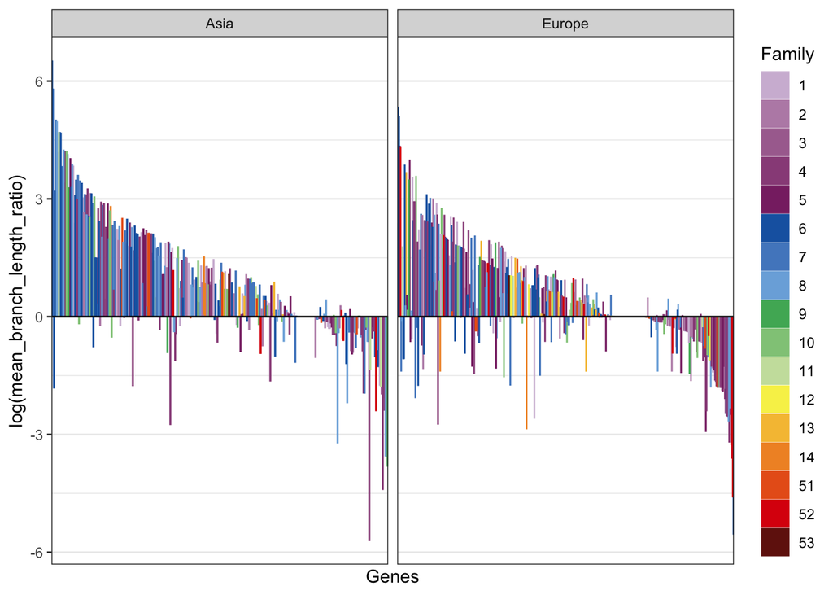

```r
p_col_function_global_order
```

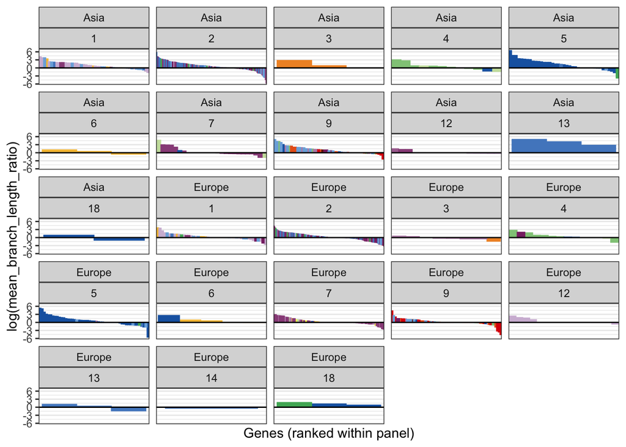

```r
p_col_by_chrom_function
```

# KW test for chromosome, family in each reiong (including post hoc Dunn/ wilcox tests)

Like the chromosome results, difficult to interpret the plots. We can do a KW to test whether or not there is a statistical difference between families, as well as chromosomes. Using slightly different datasets for both because there are some genes for which we have chromosome information but no family information.

```r
europe_gene_family <- plot_data_summary_gene_family %>% filter(region=="Europe")
asia_gene_family <-   plot_data_summary_gene_family %>% filter(region=="Asia")

europe_length <-      plot_data_summary %>% filter(region == "Europe")
asia_length <-        plot_data_summary %>% filter(region == "Asia")
```

Europe KW tests:

```r
KW_family_eur = kruskal.test(mean_branch_length_ratio ~ Family,
                    data = europe_gene_family)
print(KW_family_eur)
```

```
##
##  Kruskal-Wallis rank sum test
##
## data:  mean_branch_length_ratio by Family
## Kruskal-Wallis chi-squared = 22.034, df = 16, p-value = 0.1421
```

```r
KW_chrom_Europe = kruskal.test(mean_branch_length_ratio ~ chromosome,
                    data = europe_length)
print(KW_chrom_Europe)
```

```
##
##  Kruskal-Wallis rank sum test
##
## data:  mean_branch_length_ratio by chromosome
## Kruskal-Wallis chi-squared = 12.533, df = 11, p-value = 0.3249
```

NO significant result for Europe, for either chromosome or family.

```r
KW_family_asia = kruskal.test(mean_branch_length_ratio ~ Family,
                    data = asia_gene_family)
print(KW_family_asia)
```

```
##
##  Kruskal-Wallis rank sum test
##
## data:  mean_branch_length_ratio by Family
## Kruskal-Wallis chi-squared = 29.047, df = 15, p-value = 0.01586
```

```r
KW_chrom_aisa = kruskal.test(mean_branch_length_ratio ~ chromosome,
                    data = asia_length)
print(KW_chrom_aisa)
```

```
##
##  Kruskal-Wallis rank sum test
##
## data:  mean_branch_length_ratio by chromosome
## Kruskal-Wallis chi-squared = 21.345, df = 10, p-value = 0.01881
```

In Asia, we do see a significant result for both family and chromosome.

Post hoc: both dunn and wilcox

```r
dunn.test(asia_length$mean_branch_length_ratio,
          asia_length$chromosome,
          method="bonferroni",
          kw=TRUE)
```

```
##   Kruskal-Wallis rank sum test
##
## data: x and group
## Kruskal-Wallis chi-squared = 21.3449, df = 10, p-value = 0.02
##
##
##                     Dunn's Pairwise Comparison of x by group
##                                   (Bonferroni)
##
## Col Mean-│
## Row Mean │          1          2          3          4          5          6
## ─────────┼──────────────────────────────────────────────────────────────────
##        2 │   1.271809
##          │     1.0000
##          │
##        3 │  -0.248448  -0.612312
##          │     1.0000     1.0000
##          │
##        4 │   1.197699   0.588323   0.826546
##          │     1.0000     1.0000     1.0000
##          │
##        5 │  -0.375351  -1.612387   0.112194  -1.412587
##          │     1.0000     1.0000     1.0000     1.0000
##          │
##        6 │   0.726068   0.381701   0.709868   0.071373   0.855193
##          │     1.0000     1.0000     1.0000     1.0000     1.0000
##          │
##        7 │   2.644912   2.019401   1.256612   0.665710   2.856522   0.299427
##          │     0.2247     1.0000     1.0000     1.0000     0.1178     1.0000
##          │
##        9 │  -0.683200  -2.221048   0.026558  -1.635167  -0.249558  -0.952758
##          │     1.0000     0.7246     1.0000     1.0000     1.0000     1.0000
##          │
##       12 │   2.361535   1.779758   1.297450   0.739880   2.564361   0.371897
##          │     0.5005     1.0000     1.0000     1.0000     0.2843     1.0000
##          │
##       13 │   0.249464  -0.669168   0.342799  -0.915314   0.550038  -0.603691
##          │     1.0000     1.0000     1.0000     1.0000     1.0000     1.0000
##          │
##       18 │   1.000341   0.719818   0.952387   0.439761   1.106446   0.317462
##          │     1.0000     1.0000     1.0000     1.0000     1.0000     1.0000
## Col Mean-│
## Row Mean │          7          9         12         13
## ─────────┼────────────────────────────────────────────
##        9 │  -3.323254
##          │     0.0245*
##          │
##       12 │   0.169905   2.894546
##          │     1.0000     0.1044
##          │
##       13 │  -2.011952   0.802136  -1.900854
##          │     1.0000     1.0000     1.0000
##          │
##       18 │   0.148556   1.187341   0.076131   0.896065
##          │     1.0000     1.0000     1.0000     1.0000
##
## FWER = 0.05
## Reject Ho if adjusted p ≤ FWER/2, where (unadjusted) p = Pr(Z ≥ |z|)
```

```r
pairwise.wilcox.test(asia_length$mean_branch_length_ratio,
                     asia_length$chromosome, p.adjust.method = 'bonf')
```

[output not shown]

```
##
##  Pairwise comparisons using Wilcoxon rank sum test with continuity correction
##
## data:  asia_length$mean_branch_length_ratio and asia_length$chromosome
##
##    1     2     3     4     5     6     7     9     12    13
## 2  1.000 -     -     -     -     -     -     -     -     -
## 3  1.000 1.000 -     -     -     -     -     -     -     -
## 4  1.000 1.000 1.000 -     -     -     -     -     -     -
## 5  1.000 1.000 1.000 1.000 -     -     -     -     -     -
## 6  1.000 1.000 1.000 1.000 1.000 -     -     -     -     -
## 7  0.415 1.000 1.000 1.000 1.000 1.000 -     -     -     -
## 9  1.000 1.000 1.000 1.000 1.000 1.000 0.051 -     -     -
## 12 0.350 1.000 1.000 1.000 1.000 1.000 1.000 0.164 -     -
## 13 1.000 1.000 1.000 1.000 1.000 1.000 1.000 1.000 1.000 -
## 18 1.000 1.000 1.000 1.000 1.000 1.000 1.000 1.000 1.000 1.000
##
## P value adjustment method: bonferroni
```

Asia: diff between chromosomes 7 and 9?

```r
dunn.test(asia_gene_family$mean_branch_length_ratio,
          asia_gene_family$Family,
          method="bonferroni",
          kw=TRUE)
```

```
##   Kruskal-Wallis rank sum test
##
## data: x and group
## Kruskal-Wallis chi-squared = 29.046, df = 15, p-value = 0.02
##
##
##                     Dunn's Pairwise Comparison of x by group
##                                   (Bonferroni)
##
## Col Mean-│
## Row Mean │          1          2          3          4          5          6
## ─────────┼──────────────────────────────────────────────────────────────────
##        2 │   1.203302
##          │     1.0000
##          │
##        3 │  -0.664830  -0.935637
##          │     1.0000     1.0000
##          │
##        4 │   2.182333   0.580439   1.076528
##          │     1.0000     1.0000     1.0000
##          │
##        5 │  -0.065025  -1.079007   0.642571  -1.799249
##          │     1.0000     1.0000     1.0000     1.0000
##          │
##        6 │  -1.116514  -2.097677   0.435266  -3.185190  -0.850649
##          │     1.0000     1.0000     1.0000     0.0868     1.0000
##          │
##        7 │  -1.900931  -2.754007   0.266634  -3.939233  -1.503738  -0.766215
##          │     1.0000     0.3532     1.0000     0.0049*    1.0000     1.0000
##          │
##        8 │   0.729924  -0.527453   0.813031  -1.288399   0.660450   1.742103
##          │     1.0000     1.0000     1.0000     1.0000     1.0000     1.0000
##          │
##        9 │   1.280685   0.471309   1.074662   0.131255   1.228351   1.884962
##          │     1.0000     1.0000     1.0000     1.0000     1.0000     1.0000
##          │
##       10 │   0.005792  -0.955035   0.656383  -1.593374   0.057656   0.854593
##          │     1.0000     1.0000     1.0000     1.0000     1.0000     1.0000
##          │
##       11 │   0.614868   0.013451   0.875195  -0.272566   0.619379   1.095598
```

[output cut: 44 more lines]

```
##          │     1.0000     1.0000     1.0000     1.0000     1.0000     1.0000
## Col Mean-│
## Row Mean │         14         51         52
## ─────────┼─────────────────────────────────
##       51 │   1.009794
##          │     1.0000
##          │
##       52 │   2.200620   1.674352
##          │     1.0000     1.0000
##          │
##       53 │   0.282468  -0.329223  -1.169333
##          │     1.0000     1.0000     1.0000
##
## FWER = 0.05
## Reject Ho if adjusted p ≤ FWER/2, where (unadjusted) p = Pr(Z ≥ |z|)
```

```r
pairwise.wilcox.test(asia_gene_family$mean_branch_length_ratio,
                     asia_gene_family$Family, p.adjust.method = 'bonf')
```

[output not shown]

[output cut: 57 more lines]

[output not shown]

```
##
##  Pairwise comparisons using Wilcoxon rank sum test with continuity correction
##
## data:  asia_gene_family$mean_branch_length_ratio and asia_gene_family$Family
##
##    1     2     3     4     5     6     7     8     9     10    11    13
## 2  1.000 -     -     -     -     -     -     -     -     -     -     -
## 3  1.000 1.000 -     -     -     -     -     -     -     -     -     -
## 4  1.000 1.000 1.000 -     -     -     -     -     -     -     -     -
## 5  1.000 1.000 1.000 1.000 -     -     -     -     -     -     -     -
## 6  1.000 1.000 1.000 0.431 1.000 -     -     -     -     -     -     -
## 7  1.000 0.432 1.000 0.059 1.000 1.000 -     -     -     -     -     -
## 8  1.000 1.000 1.000 1.000 1.000 1.000 1.000 -     -     -     -     -
## 9  1.000 1.000 1.000 1.000 1.000 1.000 1.000 1.000 -     -     -     -
## 10 1.000 1.000 1.000 1.000 1.000 1.000 1.000 1.000 1.000 -     -     -
```

[output cut: 24 more lines]

Asia: significant difference between families 4 and 7

# IN PROGRESS – genes annotated by function

Okay. We think the family information is based on gene structure. Possibly metabolic pathway? But what we also have information on is the odorants associated with each gene. So, maybe we can investigate that information just for our genes of interest.

```r
anotated_genes <- read.csv("gene_odor_annotations_with_descriptions(1).csv", header=TRUE)
plot_data_odorants <- plot_data_summary %>% inner_join(anotated_genes, by="gene")
#EXAMPLE OF WHAT THE DATA LOOK LIKE FOR ONE GENE.
sOR10A1 <- anotated_genes %>% filter(gene == "sOR10A1") %>% select(Species,chromosome,gene,Matched_Receptor,Sr..No,Recognized_odorants,Perceived_odor, Odorant)
```

We know in Asia, the two gene families wit the significant different are families 4 and 7. So, maybe we can pull out just the genes in those families in Asia.

```r
genes_Asia_group_4 <- plot_data_summary_gene_family %>% filter(region == "Asia" & Family == "4") %>% pull(gene)
genes_Asia_group_7 <- plot_data_summary_gene_family %>% filter(region == "Asia" & Family == "7") %>% pull(gene)
```

```r
anotated_genes_asia_4 <- anotated_genes %>% filter(gene %in% genes_Asia_group_4) %>% filter(str_detect(Species, "Asian") == TRUE)
anotated_genes_asia_7 <- anotated_genes %>% filter(gene %in% genes_Asia_group_7) %>% filter(str_detect(Species, "Asian") == TRUE)
```

Also curious, what genes make up the highest 10% in terms of wild evolution and highest 10% in terms of domesticate evolution for both Europe and Asia. And then do the same thing, to see what smells might be associated there.

```r
ten_percent_europe <- quantile(europe_length$mean_branch_length_ratio, .1)
ninty_percent_europe <- quantile(europe_length$mean_branch_length_ratio, .9)

ten_percent_asia <- quantile(asia_length$mean_branch_length_ratio, .1)
ninty_percent_asia <- quantile(asia_length$mean_branch_length_ratio, .9)
```

```r
europe_bottom_10 <- europe_length %>% filter(mean_branch_length_ratio <=ten_percent_europe) %>% pull(gene)
europe_top_10 <-    europe_length %>% filter(mean_branch_length_ratio >=ninty_percent_europe) %>% pull(gene)

asia_bottom_10 <- asia_length %>% filter(mean_branch_length_ratio <=ten_percent_asia) %>% pull(gene)
asia_top_10 <-    asia_length %>% filter(mean_branch_length_ratio >=ninty_percent_asia) %>% pull(gene)
```

```r
anotated_genes_europe_domesticate_dominant <- anotated_genes %>% filter(gene %in% europe_bottom_10) %>% filter(str_detect(Species, "European") == TRUE)
anotated_genes_europe_wild_dominant <-        anotated_genes %>% filter(gene %in% europe_top_10)    %>% filter(str_detect(Species, "European") == TRUE)

anotated_genes_asian_domesticate_dominant <- anotated_genes %>% filter(gene %in% asia_bottom_10) %>% filter(str_detect(Species, "Asian") == TRUE)
anotated_genes_asian_wild_dominant <-        anotated_genes %>% filter(gene %in% asia_top_10)    %>% filter(str_detect(Species, "Asian") == TRUE)
```

Odorant work is still a work in progress!!!!

# Regression through the origin on gene scatterplot

Figures for paper version 1:

Going back to our quadrant plot, we want to add a linear regression. Null hypothesis is slope=0, meaning points randomly scatter around the origin. Alternative hypothesis: there is a linear relationship between the genes that are domesticated in Europe and in Asia. That is to say, that knowing something about the relationship between the wild and the domesticate branch lenght in Europe predicts something about that same relationship in Aisa.

OPTIONAL non-origin forced model

```r
model <- lm(log(mean_branch_length_ratio_Asia) ~ log(mean_branch_length_ratio_Europe), data = plot_data_summary_wide)
summary(model)
```

```
##
## Call:
## lm(formula = log(mean_branch_length_ratio_Asia) ~ log(mean_branch_length_ratio_Europe),
##     data = plot_data_summary_wide)
##
## Residuals:
##     Min      1Q  Median      3Q     Max
## -6.3968 -0.9291 -0.3260  1.0812  4.7142
##
## Coefficients:
##                                      Estimate Std. Error t value Pr(>|t|)
## (Intercept)                           0.68424    0.09491   7.209 3.88e-12 ***
## log(mean_branch_length_ratio_Europe)  0.16855    0.07220   2.334   0.0202 *
## ---
## Signif. codes:  0 '***' 0.001 '**' 0.01 '*' 0.05 '.' 0.1 ' ' 1
##
## Residual standard error: 1.652 on 329 degrees of freedom
## Multiple R-squared:  0.0163, Adjusted R-squared:  0.01331
## F-statistic:  5.45 on 1 and 329 DF,  p-value: 0.02017
```

```r
sigma(model)
```

```
## [1] 1.65228
```

```r
summary(model)$r.squared
```

```
## [1] 0.01629503
```

Now, for the model through the origin

```r
model_origin <- lm(log(mean_branch_length_ratio_Asia) ~ 0 + log(mean_branch_length_ratio_Europe), data = plot_data_summary_wide)
summary(model_origin)
```

```
##
## Call:
## lm(formula = log(mean_branch_length_ratio_Asia) ~ 0 + log(mean_branch_length_ratio_Europe),
##     data = plot_data_summary_wide)
##
## Residuals:
##     Min      1Q  Median      3Q     Max
## -5.7212 -0.2980  0.3867  1.6314  5.4495
##
## Coefficients:
##                                      Estimate Std. Error t value Pr(>|t|)
## log(mean_branch_length_ratio_Europe)  0.31973    0.07423   4.307 2.18e-05 ***
## ---
## Signif. codes:  0 '***' 0.001 '**' 0.01 '*' 0.05 '.' 0.1 ' ' 1
##
## Residual standard error: 1.775 on 330 degrees of freedom
## Multiple R-squared:  0.05323,    Adjusted R-squared:  0.05036
## F-statistic: 18.55 on 1 and 330 DF,  p-value: 2.184e-05
```

```r
r2 <- summary(model_origin)$r.squared
p  <- summary(model_origin)$coefficients[1, 4]
```

To add the predictive line to the plot

```r
predicted_df <- data.frame(asia_pred = predict(model_origin, plot_data_summary_wide), mean_branch_length_ratio_Europe=log(plot_data_summary_wide$mean_branch_length_ratio_Europe))
```

```r
lab <- paste0("R² = ", signif(r2, 3), "\n",
              "p = ", format(signif(p, 3), scientific = TRUE))


scatted_regression <- ggplot(data = plot_data_summary_wide, aes(x = log(mean_branch_length_ratio_Europe), y = log(mean_branch_length_ratio_Asia), color=quadrant)) +
  geom_point() +
  geom_line(color='red',data = predicted_df, aes(x=mean_branch_length_ratio_Europe, y=asia_pred))+
  theme_bw()+
  theme(legend.position="bottom")+
  geom_hline(yintercept = 0)+
  geom_vline(xintercept = 0)+
  labs(x="Europe: log(wild bl /domesticate bl)",y="Asia: log(wild bl /domesticate bl)", title = "Branch length ratio by gene and continent", subtitle = "linear model forced through the origin", color="")+
  annotate("text", x = -Inf, y = Inf, hjust = -0.1, vjust = 1.5,
           label = lab, size = 3)+
  scale_color_mediumcontrast(guide = guide_legend(nrow = 2))

ggsave(
  filename = paste0("for_paper_plots/scatter_regression.png"),
  plot = scatted_regression,
  width = 6,
  height = 6,
  limitsize = FALSE)
```